# Federated Learning for Exact Bayesian Linear Regression

Sudipto Banerjee

*Note:* To generate this HTML file, run `renderFederatedLearning.sh` in the terminal from the `src/bigDataRegression/federatedLearning/run` directory. Alternatively find the source `Rmd` and `R` files in that same folder starting from the `BGC_2023` GitHub home.

```bash
# Navigate to the directory and run the compilation script
cd src/bigDataRegression/federatedLearning/run
./renderFederatedLearning.sh
```

## Theory: Federated Learning for Bayesian Regression

In a Federated Learning (FL) paradigm, the data is decentralized. Instead of having a single machine load blocks of data sequentially, we have a central server communicating with $T$ distinct clients (e.g., edge devices, hospitals, or local servers). The raw data $(y_t, X_t)$ legally or practically cannot leave client $t$.

### 1. Local Client Computations

Suppose the central server holds the initial prior parameters: $M_0^{-1}$, $m_0$, $a_0$, and $b_0$.

In FL, we do not need to broadcast these priors to the clients for them to do their heavy lifting. Each client $t$ possesses its own local dataset $(y_t, X_t)$ of size $n_t$. The client computes three localized sufficient statistics:

1. **Precision Matrix Update:** $\Delta M_t^{-1} = X_t^{\top}V_t^{-1}X_t$
2. **Mean Vector Update:** $\Delta m_t = X_t^{\top}V_t^{-1}y_t$
3. **Sum of Squares:** $\Delta Q_t = y_t^{\top}V_t^{-1}y_t$

Client $t$ then sends only the tuple $(\Delta M_t^{-1}, \Delta m_t, \Delta Q_t, n_t)$ back to the central server.

> **Note:** This preserves privacy and vastly reduces communication overhead. For a dataset with millions of rows but $p=10$ predictors, the client only transmits a $10 \times 10$ matrix, a $10 \times 1$ vector, and two scalars.

### 2. Server Aggregation

Once the server receives the local statistics from all $T$ clients, it aggregates them to form the exact global posterior.

Because the data across clients are independent given $\theta$, the global precision matrix and natural mean vector are simple summations:
$$\begin{aligned}
M_T^{-1} &= M_0^{-1} + \sum_{t=1}^T \Delta M_t^{-1} \\
m_T &= m_0 + \sum_{t=1}^T \Delta m_t
\end{aligned}$$

The shape parameter for the Inverse-Gamma distribution updates simply by summing the local sample sizes:
$$a_T = a_0 + \frac{1}{2} \sum_{t=1}^T n_t$$

The magic of the exact federated approach happens in the scale parameter $b_T$. If we sum the sequential updates across all $T$ clients, the intermediate prior-posterior quadratic forms cancel out in a **telescoping sum**, leaving only the initial prior and the final global posterior states:
$$\sum_{t=1}^T q_t = \left( \sum_{t=1}^T \Delta Q_t \right) +
m_0^{\top}M_0 m_0 - m_T^{\top}M_T m_T$$

Thus, the server computes the global scale parameter in one step:
$$b_T = b_0 + \frac{1}{2} \left( \sum_{t=1}^T \Delta Q_t + m_0^{\top}M_0
m_0 - m_T^{\top}M_T m_T \right)$$

### 3. Global Posterior Sampling

With $M_T$, $m_T$, $a_T$, and $b_T$ fully assembled at the central server, the global posterior is mathematically indistinguishable from a model that centralized all data in one place.

The server (or any client that requests the final model) can now draw $N$ exact samples from the joint posterior:
$$\begin{aligned}
\sigma^2_{(i)} &\sim IG(a_T, b_T) \\
\beta_{(i)} \mid \sigma^2_{(i)} &\sim N\left(M_T m_T, \sigma^2_{(i)}
M_T\right)
\end{aligned}$$

```r
knitr::opts_chunk$set(echo = TRUE, warning = FALSE, message = FALSE)
library(knitr)
library(ggplot2)
library(dplyr)
# Source the federated learning sampler
source("../src/flSampling.r")
```

## Section 1: Unscaled Data Analysis

First, we will process the raw dataset to prove that Federated Learning perfectly matches a centralized approach. We simulate 10 decentralized clients and compare the FL aggregated posterior against an exact centralized model.

```r
# Define universal priors and parameters
p <- 9 # Intercept + 8 predictors
M0_inv <- matrix(0, nrow = p, ncol = p)
m0 <- rep(0, p)
a0 <- 0.01
b0 <- 0.01
N_samples <- 5000
params_names <- c("Intercept", "X1", "X2", "X3", "X4", "X5", "X6", "Lat", "Longi", "sigma2")
```

```r
# 1. Load Data
data <- read.table("../data/data.txt", header = TRUE)
X_full <- as.matrix(cbind(Intercept = 1, data[, c("X1", "X2", "X3", "X4", "X5", "X6", "Lat", "Longi")]))
y_full <- as.numeric(data$Y)

# 2. Partition into 10 clients
T_clients <- 10
block_size <- 130
total_n <- nrow(X_full)
group_indices <- c(rep(1:(T_clients - 1), each = block_size),
                   rep(T_clients, total_n - (T_clients - 1) * block_size))

X_list <- lapply(split(as.data.frame(X_full), group_indices), as.matrix)
y_list <- unname(split(y_full, group_indices))

# 3. CLIENT SIDE: Compute local stats using mapply
client_stats <- mapply(compute_local_stats, X_list, y_list, SIMPLIFY = FALSE)

# 4. SERVER SIDE: Aggregate Federated Learning (T = 10)
set.seed(123)
fl_results <- flSampler(client_stats_list = client_stats,
                        M0_inv = M0_inv, m0 = m0, a0 = a0, b0 = b0, N_samples = N_samples)
draws_fl <- as.data.frame(fl_results$draws)
colnames(draws_fl) <- params_names

summary_fl <- data.frame(
  Parameter = colnames(draws_fl),
  Mean_FL = colMeans(draws_fl),
  SD_FL = apply(draws_fl, 2, sd)
)

# 5. EXACT CENTRALIZED: Compute local stats on the entire dataset at once (T = 1)
centralized_stats <- list(compute_local_stats(X_full, y_full))
set.seed(123) # Match seed for exact draw comparison
central_results <- flSampler(client_stats_list = centralized_stats,
                             M0_inv = M0_inv, m0 = m0, a0 = a0, b0 = b0, N_samples = N_samples)
draws_central <- as.data.frame(central_results$draws)
colnames(draws_central) <- params_names

summary_central <- data.frame(
  Parameter = colnames(draws_central),
  Mean_Central = colMeans(draws_central),
  SD_Central = apply(draws_central, 2, sd)
)

# 6. Compare Summaries
comparison_df <- merge(summary_central, summary_fl, by = "Parameter")
kable(comparison_df, digits = 4, caption = "Unscaled Posterior Comparison: Centralized vs Federated")
```

Unscaled Posterior Comparison: Centralized vs Federated

| Parameter | Mean_Central | SD_Central | Mean_FL | SD_FL |
| --- | --- | --- | --- | --- |
| Intercept | -555.1163 | 87.3389 | -555.1161 | 87.3389 |
| Lat | -2.4056 | 0.2973 | -2.4056 | 0.2973 |
| Longi | -5.4183 | 0.7839 | -5.4183 | 0.7839 |
| sigma2 | 0.0228 | 0.0009 | 0.0228 | 0.0009 |
| X1 | 0.0610 | 0.0012 | 0.0610 | 0.0012 |
| X2 | -0.0018 | 0.0003 | -0.0018 | 0.0003 |
| X3 | -0.0492 | 0.0082 | -0.0492 | 0.0082 |
| X4 | -0.0688 | 0.0087 | -0.0688 | 0.0087 |
| X5 | 0.0287 | 0.0093 | 0.0287 | 0.0093 |
| X6 | 4.7258 | 0.8772 | 4.7258 | 0.8772 |

### Q-Q Plots for Unscaled Distributional Validation

To visually confirm that the resulting distributions are practically indistinguishable, we plot the sorted posterior samples against one another. The 45-degree line represents perfect equality.

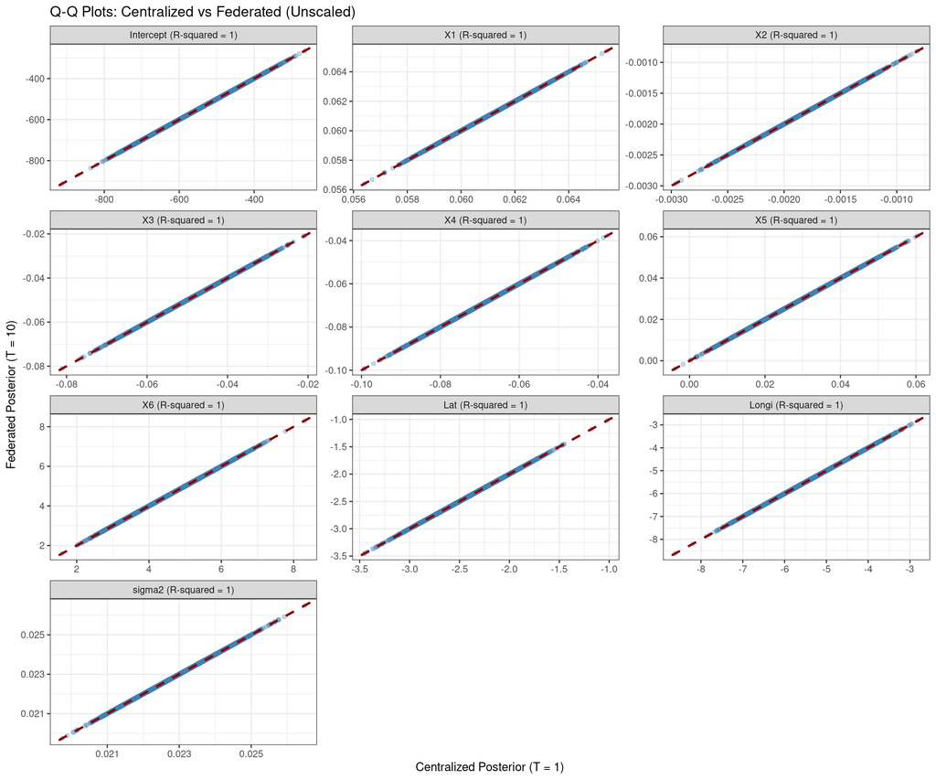

```r
# Vectorized alignment and R-squared calculation
plot_data_list <- lapply(params_names, function(param) {
  q_central <- sort(draws_central[[param]])
  q_fl <- sort(draws_fl[[param]])
  r_squared <- cor(q_central, q_fl)^2

  data.frame(
    Facet_Label = paste0(param, " (R-squared = ", round(r_squared, 6), ")"),
    Centralized = q_central,
    Federated = q_fl
  )
})

df_plot_all <- do.call(rbind, plot_data_list)
df_plot_all$Facet_Label <- factor(df_plot_all$Facet_Label, levels = unique(df_plot_all$Facet_Label))

ggplot(df_plot_all, aes(x = Centralized, y = Federated)) +
  geom_point(alpha = 0.3, color = "steelblue") +
  geom_abline(slope = 1, intercept = 0, color = "darkred", linetype = "dashed", linewidth = 1) +
  facet_wrap(~ Facet_Label, scales = "free", ncol = 3) +
  labs(
    title = "Q-Q Plots: Centralized vs Federated (Unscaled)",
    x = "Centralized Posterior (T = 1)",
    y = "Federated Posterior (T = 10)"
  ) +
  theme_bw()
```

## Section 2: Scaled and Centered Data Analysis

Centering and scaling the predictor matrix provides substantial numerical stability by standardizing the scales of all covariates. We now demonstrate the Federated Learning workflow applied to scaled predictors, guaranteeing that the mathematical equivalence still perfectly holds.

```r
# 1. Center and Scale covariates (exclude intercept)
covariates <- data[, c("X1", "X2", "X3", "X4", "X5", "X6", "Lat", "Longi")]
X_scaled_full <- as.matrix(cbind(Intercept = 1, scale(covariates)))

# 2. Partition scaled data into 10 clients
X_list_scaled <- lapply(split(as.data.frame(X_scaled_full), group_indices), as.matrix)

# 3. CLIENT SIDE: Compute local stats on scaled data
client_stats_scaled <- mapply(compute_local_stats, X_list_scaled, y_list, SIMPLIFY = FALSE)

# 4. SERVER SIDE: Aggregate Federated Learning (T = 10)
set.seed(123)
fl_results_scaled <- flSampler(client_stats_list = client_stats_scaled,
                               M0_inv = M0_inv, m0 = m0, a0 = a0, b0 = b0, N_samples = N_samples)
draws_fl_scaled <- as.data.frame(fl_results_scaled$draws)
colnames(draws_fl_scaled) <- params_names

summary_fl_scaled <- data.frame(
  Parameter = colnames(draws_fl_scaled),
  Mean_FL_Scaled = colMeans(draws_fl_scaled),
  SD_FL_Scaled = apply(draws_fl_scaled, 2, sd)
)

# 5. EXACT CENTRALIZED: Compute local stats on entire scaled dataset at once (T = 1)
centralized_stats_scaled <- list(compute_local_stats(X_scaled_full, y_full))
set.seed(123)
central_results_scaled <- flSampler(client_stats_list = centralized_stats_scaled,
                                    M0_inv = M0_inv, m0 = m0, a0 = a0, b0 = b0, N_samples = N_samples)
draws_central_scaled <- as.data.frame(central_results_scaled$draws)
colnames(draws_central_scaled) <- params_names

summary_central_scaled <- data.frame(
  Parameter = colnames(draws_central_scaled),
  Mean_Central_Scaled = colMeans(draws_central_scaled),
  SD_Central_Scaled = apply(draws_central_scaled, 2, sd)
)

# 6. Compare Summaries
comparison_scaled_df <- merge(summary_central_scaled, summary_fl_scaled, by = "Parameter")
kable(comparison_scaled_df, digits = 4, caption = "Scaled Posterior Comparison: Centralized vs Federated")
```

Scaled Posterior Comparison: Centralized vs Federated

| Parameter | Mean_Central_Scaled | SD_Central_Scaled | Mean_FL_Scaled | SD_FL_Scaled |
| --- | --- | --- | --- | --- |
| Intercept | 11.6839 | 0.0040 | 11.6839 | 0.0040 |
| Lat | -0.0649 | 0.0080 | -0.0649 | 0.0080 |
| Longi | -0.1457 | 0.0211 | -0.1457 | 0.0211 |
| sigma2 | 0.0228 | 0.0009 | 0.0228 | 0.0009 |
| X1 | 0.2964 | 0.0058 | 0.2964 | 0.0058 |
| X2 | -0.0385 | 0.0060 | -0.0385 | 0.0060 |
| X3 | -0.0347 | 0.0058 | -0.0347 | 0.0058 |
| X4 | -0.0327 | 0.0041 | -0.0327 | 0.0041 |
| X5 | 0.0128 | 0.0042 | 0.0128 | 0.0042 |
| X6 | 0.1117 | 0.0207 | 0.1117 | 0.0207 |

### Q-Q Plots for Scaled Distributional Validation

To ensure the exact federated approach holds true for centered and scaled data, we plot the sorted posterior samples against each other.

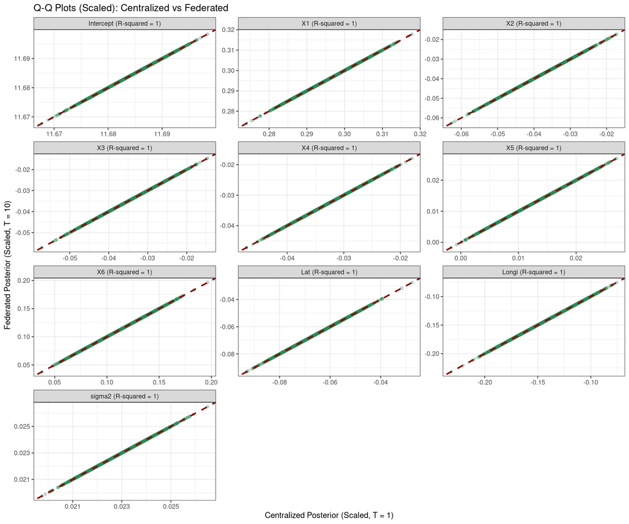

```r
# Vectorized alignment and R-squared calculation for scaled data
plot_data_list_scaled <- lapply(params_names, function(param) {
  q_central_scaled <- sort(draws_central_scaled[[param]])
  q_fl_scaled <- sort(draws_fl_scaled[[param]])
  r_squared_scaled <- cor(q_central_scaled, q_fl_scaled)^2

  data.frame(
    Facet_Label = paste0(param, " (R-squared = ", round(r_squared_scaled, 6), ")"),
    Centralized = q_central_scaled,
    Federated = q_fl_scaled
  )
})

df_plot_all_scaled <- do.call(rbind, plot_data_list_scaled)
df_plot_all_scaled$Facet_Label <- factor(df_plot_all_scaled$Facet_Label, levels = unique(df_plot_all_scaled$Facet_Label))

ggplot(df_plot_all_scaled, aes(x = Centralized, y = Federated)) +
  geom_point(alpha = 0.3, color = "seagreen") +
  geom_abline(slope = 1, intercept = 0, color = "darkred", linetype = "dashed", linewidth = 1) +
  facet_wrap(~ Facet_Label, scales = "free", ncol = 3) +
  labs(
    title = "Q-Q Plots (Scaled): Centralized vs Federated",
    x = "Centralized Posterior (Scaled, T = 1)",
    y = "Federated Posterior (Scaled, T = 10)"
  ) +
  theme_bw()
```